# Project: TMDb movie data

- Introduction
- Data Wrangling
- Exploratory Data Analysis
- Conclusions

## Introduction

In this project i will use TMDb movie dataset.

It contains all the details like the budget, revenue, cast, director(s), etc of about 10,000 movies.

**Questions to be answered:**

```python
# importing all the neccessary libraries

import pandas as pd
import numpy as np
import matplotlib.pyplot as plt
import seaborn as sns
# this makes sure all the data visualisations are plotted in the notebook and not in a seperate window
%matplotlib inline

#Load the Dataset
df= pd.read_csv("tmdb-movies.csv")
```

## Data Wrangling

### General Properties

```python
# Having a look at the first 50 rows of the dataset with the provided columns intact
df.head(50)
```

|  | id | imdb_id | popularity | budget | revenue | original_title | cast | homepage | director | tagline | ... | overview | runtime | genres | production_companies | release_date | vote_count | vote_average | release_year | budget_adj | revenue_adj |
| --- | --- | --- | --- | --- | --- | --- | --- | --- | --- | --- | --- | --- | --- | --- | --- | --- | --- | --- | --- | --- | --- |
| 0 | 135397 | tt0369610 | 32.985763 | 150000000 | 1513528810 | Jurassic World | Chris Pratt\|Bryce Dallas Howard\|Irrfan Khan\|Vi... | http://www.jurassicworld.com/ | Colin Trevorrow | The park is open. | ... | Twenty-two years after the events of Jurassic ... | 124 | Action\|Adventure\|Science Fiction\|Thriller | Universal Studios\|Amblin Entertainment\|Legenda... | 6/9/15 | 5562 | 6.5 | 2015 | 1.379999e+08 | 1.392446e+09 |
| 1 | 76341 | tt1392190 | 28.419936 | 150000000 | 378436354 | Mad Max: Fury Road | Tom Hardy\|Charlize Theron\|Hugh Keays-Byrne\|Nic... | http://www.madmaxmovie.com/ | George Miller | What a Lovely Day. | ... | An apocalyptic story set in the furthest reach... | 120 | Action\|Adventure\|Science Fiction\|Thriller | Village Roadshow Pictures\|Kennedy Miller Produ... | 5/13/15 | 6185 | 7.1 | 2015 | 1.379999e+08 | 3.481613e+08 |
| 2 | 262500 | tt2908446 | 13.112507 | 110000000 | 295238201 | Insurgent | Shailene Woodley\|Theo James\|Kate Winslet\|Ansel... | http://www.thedivergentseries.movie/#insurgent | Robert Schwentke | One Choice Can Destroy You | ... | Beatrice Prior must confront her inner demons ... | 119 | Adventure\|Science Fiction\|Thriller | Summit Entertainment\|Mandeville Films\|Red Wago... | 3/18/15 | 2480 | 6.3 | 2015 | 1.012000e+08 | 2.716190e+08 |
| 3 | 140607 | tt2488496 | 11.173104 | 200000000 | 2068178225 | Star Wars: The Force Awakens | Harrison Ford\|Mark Hamill\|Carrie Fisher\|Adam D... | http://www.starwars.com/films/star-wars-episod... | J.J. Abrams | Every generation has a story. | ... | Thirty years after defeating the Galactic Empi... | 136 | Action\|Adventure\|Science Fiction\|Fantasy | Lucasfilm\|Truenorth Productions\|Bad Robot | 12/15/15 | 5292 | 7.5 | 2015 | 1.839999e+08 | 1.902723e+09 |
| 4 | 168259 | tt2820852 | 9.335014 | 190000000 | 1506249360 | Furious 7 | Vin Diesel\|Paul Walker\|Jason Statham\|Michelle ... | http://www.furious7.com/ | James Wan | Vengeance Hits Home | ... | Deckard Shaw seeks revenge against Dominic Tor... | 137 | Action\|Crime\|Thriller | Universal Pictures\|Original Film\|Media Rights ... | 4/1/15 | 2947 | 7.3 | 2015 | 1.747999e+08 | 1.385749e+09 |
| 5 | 281957 | tt1663202 | 9.110700 | 135000000 | 532950503 | The Revenant | Leonardo DiCaprio\|Tom Hardy\|Will Poulter\|Domhn... | http://www.foxmovies.com/movies/the-revenant | Alejandro González Iñárritu | (n. One who has returned, as if from the dead.) | ... | In the 1820s, a frontiersman, Hugh Glass, sets... | 156 | Western\|Drama\|Adventure\|Thriller | Regency Enterprises\|Appian Way\|CatchPlay\|Anony... | 12/25/15 | 3929 | 7.2 | 2015 | 1.241999e+08 | 4.903142e+08 |
| 6 | 87101 | tt1340138 | 8.654359 | 155000000 | 440603537 | Terminator Genisys | Arnold Schwarzenegger\|Jason Clarke\|Emilia Clar... | http://www.terminatormovie.com/ | Alan Taylor | Reset the future | ... | The year is 2029. John Connor, leader of the r... | 125 | Science Fiction\|Action\|Thriller\|Adventure | Paramount Pictures\|Skydance Productions | 6/23/15 | 2598 | 5.8 | 2015 | 1.425999e+08 | 4.053551e+08 |
| 7 | 286217 | tt3659388 | 7.667400 | 108000000 | 595380321 | The Martian | Matt Damon\|Jessica Chastain\|Kristen Wiig\|Jeff ... | http://www.foxmovies.com/movies/the-martian | Ridley Scott | Bring Him Home | ... | During a manned mission to Mars, Astronaut Mar... | 141 | Drama\|Adventure\|Science Fiction | Twentieth Century Fox Film Corporation\|Scott F... | 9/30/15 | 4572 | 7.6 | 2015 | 9.935996e+07 | 5.477497e+08 |
| 8 | 211672 | tt2293640 | 7.404165 | 74000000 | 1156730962 | Minions | Sandra Bullock\|Jon Hamm\|Michael Keaton\|Allison... | http://www.minionsmovie.com/ | Kyle Balda\|Pierre Coffin | Before Gru, they had a history of bad bosses | ... | Minions Stuart, Kevin and Bob are recruited by... | 91 | Family\|Animation\|Adventure\|Comedy | Universal Pictures\|Illumination Entertainment | 6/17/15 | 2893 | 6.5 | 2015 | 6.807997e+07 | 1.064192e+09 |
| 9 | 150540 | tt2096673 | 6.326804 | 175000000 | 853708609 | Inside Out | Amy Poehler\|Phyllis Smith\|Richard Kind\|Bill Ha... | http://movies.disney.com/inside-out | Pete Docter | Meet the little voices inside your head. | ... | Growing up can be a bumpy road, and it's no ex... | 94 | Comedy\|Animation\|Family | Walt Disney Pictures\|Pixar Animation Studios\|W... | 6/9/15 | 3935 | 8.0 | 2015 | 1.609999e+08 | 7.854116e+08 |
| 10 | 206647 | tt2379713 | 6.200282 | 245000000 | 880674609 | Spectre | Daniel Craig\|Christoph Waltz\|Léa Seydoux\|Ralp... | http://www.sonypictures.com/movies/spectre/ | Sam Mendes | A Plan No One Escapes | ... | A cryptic message from Bond’s past sends him... | 148 | Action\|Adventure\|Crime | Columbia Pictures\|Danjaq\|B24 | 10/26/15 | 3254 | 6.2 | 2015 | 2.253999e+08 | 8.102203e+08 |
| 11 | 76757 | tt1617661 | 6.189369 | 176000003 | 183987723 | Jupiter Ascending | Mila Kunis\|Channing Tatum\|Sean Bean\|Eddie Redm... | http://www.jupiterascending.com | Lana Wachowski\|Lilly Wachowski | Expand your universe. | ... | In a universe where human genetic material is ... | 124 | Science Fiction\|Fantasy\|Action\|Adventure | Village Roadshow Pictures\|Dune Entertainment\|A... | 2/4/15 | 1937 | 5.2 | 2015 | 1.619199e+08 | 1.692686e+08 |
| 12 | 264660 | tt0470752 | 6.118847 | 15000000 | 36869414 | Ex Machina | Domhnall Gleeson\|Alicia Vikander\|Oscar Isaac\|S... | http://exmachina-movie.com/ | Alex Garland | There is nothing more human than the will to s... | ... | Caleb, a 26 year old coder at the world's larg... | 108 | Drama\|Science Fiction | DNA Films\|Universal Pictures International (UP... | 1/21/15 | 2854 | 7.6 | 2015 | 1.379999e+07 | 3.391985e+07 |
| 13 | 257344 | tt2120120 | 5.984995 | 88000000 | 243637091 | Pixels | Adam Sandler\|Michelle Monaghan\|Peter Dinklage\|... | http://www.pixels-movie.com/ | Chris Columbus | Game On. | ... | Video game experts are recruited by the milita... | 105 | Action\|Comedy\|Science Fiction | Columbia Pictures\|Happy Madison Productions | 7/16/15 | 1575 | 5.8 | 2015 | 8.095996e+07 | 2.241460e+08 |
| 14 | 99861 | tt2395427 | 5.944927 | 280000000 | 1405035767 | Avengers: Age of Ultron | Robert Downey Jr.\|Chris Hemsworth\|Mark Ruffalo... | http://marvel.com/movies/movie/193/avengers_ag... | Joss Whedon | A New Age Has Come. | ... | When Tony Stark tries to jumpstart a dormant p... | 141 | Action\|Adventure\|Science Fiction | Marvel Studios\|Prime Focus\|Revolution Sun Studios | 4/22/15 | 4304 | 7.4 | 2015 | 2.575999e+08 | 1.292632e+09 |
| 15 | 273248 | tt3460252 | 5.898400 | 44000000 | 155760117 | The Hateful Eight | Samuel L. Jackson\|Kurt Russell\|Jennifer Jason ... | http://thehatefuleight.com/ | Quentin Tarantino | No one comes up here without a damn good reason. | ... | Bounty hunters seek shelter from a raging bliz... | 167 | Crime\|Drama\|Mystery\|Western | Double Feature Films\|The Weinstein Company\|Fil... | 12/25/15 | 2389 | 7.4 | 2015 | 4.047998e+07 | 1.432992e+08 |
| 16 | 260346 | tt2446042 | 5.749758 | 48000000 | 325771424 | Taken 3 | Liam Neeson\|Forest Whitaker\|Maggie Grace\|Famke... | http://www.taken3movie.com/ | Olivier Megaton | It Ends Here | ... | Ex-government operative Bryan Mills finds his ... | 109 | Crime\|Action\|Thriller | Twentieth Century Fox Film Corporation\|M6 Film... | 1/1/15 | 1578 | 6.1 | 2015 | 4.415998e+07 | 2.997096e+08 |
| 17 | 102899 | tt0478970 | 5.573184 | 130000000 | 518602163 | Ant-Man | Paul Rudd\|Michael Douglas\|Evangeline Lilly\|Cor... | http://marvel.com/movies/movie/180/ant-man | Peyton Reed | Heroes Don't Get Any Bigger | ... | Armed with the astonishing ability to shrink i... | 115 | Science Fiction\|Action\|Adventure | Marvel Studios | 7/14/15 | 3779 | 7.0 | 2015 | 1.195999e+08 | 4.771138e+08 |
| 18 | 150689 | tt1661199 | 5.556818 | 95000000 | 542351353 | Cinderella | Lily James\|Cate Blanchett\|Richard Madden\|Helen... | NaN | Kenneth Branagh | Midnight is just the beginning. | ... | When her father unexpectedly passes away, youn... | 112 | Romance\|Fantasy\|Family\|Drama | Walt Disney Pictures\|Genre Films\|Beagle Pug Fi... | 3/12/15 | 1495 | 6.8 | 2015 | 8.739996e+07 | 4.989630e+08 |
| 19 | 131634 | tt1951266 | 5.476958 | 160000000 | 650523427 | The Hunger Games: Mockingjay - Part 2 | Jennifer Lawrence\|Josh Hutcherson\|Liam Hemswor... | http://www.thehungergames.movie/ | Francis Lawrence | The fire will burn forever. | ... | With the nation of Panem in a full scale war, ... | 136 | War\|Adventure\|Science Fiction | Studio Babelsberg\|StudioCanal\|Lionsgate\|Walt D... | 11/18/15 | 2380 | 6.5 | 2015 | 1.471999e+08 | 5.984813e+08 |
| 20 | 158852 | tt1964418 | 5.462138 | 190000000 | 209035668 | Tomorrowland | Britt Robertson\|George Clooney\|Raffey Cassidy\|... | http://movies.disney.com/tomorrowland | Brad Bird | Imagine a world where nothing is impossible. | ... | Bound by a shared destiny, a bright, optimisti... | 130 | Action\|Family\|Science Fiction\|Adventure\|Mystery | Walt Disney Pictures\|Babieka\|A113 | 5/19/15 | 1899 | 6.2 | 2015 | 1.747999e+08 | 1.923127e+08 |
| 21 | 307081 | tt1798684 | 5.337064 | 30000000 | 91709827 | Southpaw | Jake Gyllenhaal\|Rachel McAdams\|Forest Whitaker... | NaN | Antoine Fuqua | Believe in Hope. | ... | Billy "The Great" Hope, the reigning junior mi... | 123 | Action\|Drama | Escape Artists\|Riche-Ludwig Productions | 6/15/15 | 1386 | 7.3 | 2015 | 2.759999e+07 | 8.437300e+07 |
| 22 | 254128 | tt2126355 | 4.907832 | 110000000 | 470490832 | San Andreas | Dwayne Johnson\|Alexandra Daddario\|Carla Gugino... | http://www.sanandreasmovie.com/ | Brad Peyton | A rescue pilot survived an earthquake, this is... | ... | In the aftermath of a massive earthquake in Ca... | 114 | Action\|Drama\|Thriller | New Line Cinema\|Village Roadshow Pictures\|Warn... | 5/27/15 | 2060 | 6.1 | 2015 | 1.012000e+08 | 4.328514e+08 |
| 23 | 216015 | tt2322441 | 4.710402 | 40000000 | 569651467 | Fifty Shades of Grey | Dakota Johnson\|Jamie Dornan\|Jennifer Ehle\|Eloi... | https://www.facebook.com/fiftyshadesofgreymovie | Sam Taylor-Johnson | Are you curious? | ... | When college senior Anastasia Steele steps in ... | 125 | Drama\|Romance | Focus Features\|Trigger Street Productions\|Mich... | 2/11/15 | 1865 | 5.3 | 2015 | 3.679998e+07 | 5.240791e+08 |
| 24 | 318846 | tt1596363 | 4.648046 | 28000000 | 133346506 | The Big Short | Christian Bale\|Steve Carell\|Ryan Gosling\|Brad ... | http://www.thebigshortmovie.com/ | Adam McKay | This is a true story. | ... | The men who made millions from a global econom... | 130 | Comedy\|Drama | Paramount Pictures\|Plan B Entertainment\|Regenc... | 12/11/15 | 1545 | 7.3 | 2015 | 2.575999e+07 | 1.226787e+08 |
| 25 | 177677 | tt2381249 | 4.566713 | 150000000 | 682330139 | Mission: Impossible - Rogue Nation | Tom Cruise\|Jeremy Renner\|Simon Pegg\|Rebecca Fe... | http://www.missionimpossible.com | Christopher McQuarrie | Desperate Times. Desperate Measures. | ... | Ethan and team take on their most impossible m... | 131 | Action | Paramount Pictures\|Skydance Productions\|China ... | 7/23/15 | 2349 | 7.1 | 2015 | 1.379999e+08 | 6.277435e+08 |
| 26 | 214756 | tt2637276 | 4.564549 | 68000000 | 215863606 | Ted 2 | Mark Wahlberg\|Seth MacFarlane\|Amanda Seyfried\|... | NaN | Seth MacFarlane | Ted is Coming, Again. | ... | Newlywed couple Ted and Tami-Lynn want to have... | 115 | Comedy | Universal Pictures\|Media Rights Capital\|Fuzzy ... | 6/25/15 | 1666 | 6.3 | 2015 | 6.255997e+07 | 1.985944e+08 |
| 27 | 207703 | tt2802144 | 4.503789 | 81000000 | 403802136 | Kingsman: The Secret Service | Taron Egerton\|Colin Firth\|Samuel L. Jackson\|Mi... | http://www.kingsmanmovie.com/ | Matthew Vaughn | Manners maketh man. | ... | The story of a super-secret spy organization t... | 130 | Crime\|Comedy\|Action\|Adventure | Twentieth Century Fox Film Corporation\|Marv Fi... | 1/24/15 | 3833 | 7.6 | 2015 | 7.451997e+07 | 3.714978e+08 |
| 28 | 314365 | tt1895587 | 4.062293 | 20000000 | 88346473 | Spotlight | Mark Ruffalo\|Michael Keaton\|Rachel McAdams\|Lie... | http://www.spotlightthefilm.com | Tom McCarthy | Break the story. Break the silence. | ... | The true story of how The Boston Globe uncover... | 128 | Drama\|Thriller\|History | Participant Media\|Open Road Films\|Anonymous Co... | 11/6/15 | 1559 | 7.8 | 2015 | 1.839999e+07 | 8.127872e+07 |
| 29 | 294254 | tt4046784 | 3.968891 | 61000000 | 311256926 | Maze Runner: The Scorch Trials | Dylan O'Brien\|Kaya Scodelario\|Thomas Brodie-Sa... | http://mazerunnermovies.com | Wes Ball | The Maze Was Just the Beginning. | ... | Thomas and his fellow Gladers face their great... | 132 | Action\|Science Fiction\|Thriller | Gotham Group\|Temple Hill Entertainment\|TSG Ent... | 9/9/15 | 1849 | 6.4 | 2015 | 5.611998e+07 | 2.863562e+08 |
| 30 | 280996 | tt3168230 | 3.927333 | 0 | 29355203 | Mr. Holmes | Ian McKellen\|Milo Parker\|Laura Linney\|Hattie M... | http://www.mrholmesfilm.com/ | Bill Condon | The man behind the myth | ... | The story is set in 1947, following a long-ret... | 103 | Mystery\|Drama | BBC Films\|See-Saw Films\|FilmNation Entertainme... | 6/19/15 | 425 | 6.4 | 2015 | 0.000000e+00 | 2.700677e+07 |
| 31 | 198184 | tt1823672 | 3.899557 | 49000000 | 102069268 | Chappie | Sharlto Copley\|Dev Patel\|Ninja\|Yolandi Visser\|... | http://www.chappie-movie.com | Neill Blomkamp | I am consciousness. I am alive. I am Chappie. | ... | Every child comes into the world full of promi... | 120 | Crime\|Action\|Science Fiction | Columbia Pictures\|Media Rights Capital\|Sony Pi... | 3/4/15 | 1990 | 6.6 | 2015 | 4.507998e+07 | 9.390369e+07 |
| 32 | 254470 | tt2848292 | 3.877764 | 29000000 | 287506194 | Pitch Perfect 2 | Anna Kendrick\|Rebel Wilson\|Hailee Steinfeld\|Br... | NaN | Elizabeth Banks | We're back pitches | ... | The Bellas are back, and they are better than ... | 115 | Comedy\|Music | Universal Pictures\|Gold Circle Films\|Brownston... | 5/7/15 | 1264 | 6.8 | 2015 | 2.667999e+07 | 2.645056e+08 |
| 33 | 296098 | tt3682448 | 3.648210 | 40000000 | 162610473 | Bridge of Spies | Tom Hanks\|Mark Rylance\|Amy Ryan\|Alan Alda\|Seba... | NaN | Steven Spielberg | In the shadow of war, one man showed the world... | ... | During the Cold War, the Soviet Union captures... | 141 | Thriller\|Drama | DreamWorks SKG\|Amblin Entertainment\|Studio Bab... | 10/15/15 | 1638 | 7.1 | 2015 | 3.679998e+07 | 1.496016e+08 |
| 34 | 257445 | tt1051904 | 3.644541 | 58000000 | 150170815 | Goosebumps | Jack Black\|Dylan Minnette\|Odeya Rush\|Amy Ryan\|... | http://www.goosebumps-movie.com/ | Rob Letterman | The stories are alive. | ... | A teenager teams up with the daughter of young... | 103 | Adventure\|Horror\|Comedy | Columbia Pictures\|Original Film\|Scholastic Ent... | 8/5/15 | 600 | 6.2 | 2015 | 5.335998e+07 | 1.381571e+08 |
| 35 | 264644 | tt3170832 | 3.557846 | 6000000 | 35401758 | Room | Brie Larson\|Jacob Tremblay\|Joan Allen\|Sean Bri... | http://www.roomthemovie.com | Lenny Abrahamson | Love knows no boundaries | ... | Jack is a young boy of 5 years old who has liv... | 117 | Drama\|Thriller | Element Pictures\|No Trace Camping\|A24\|Duperele... | 10/16/15 | 1520 | 8.0 | 2015 | 5.519998e+06 | 3.256960e+07 |
| 36 | 339527 | tt1291570 | 3.358321 | 0 | 22354572 | Solace | Abbie Cornish\|Jeffrey Dean Morgan\|Colin Farrel... | NaN | Afonso Poyart | A serial killer who can see your future, a psy... | ... | A psychic doctor, John Clancy, works with an F... | 101 | Crime\|Drama\|Mystery | Eden Rock Media\|FilmNation Entertainment\|Flynn... | 9/3/15 | 474 | 6.2 | 2015 | 0.000000e+00 | 2.056620e+07 |
| 37 | 105864 | tt1979388 | 3.339135 | 175000000 | 331926147 | The Good Dinosaur | Raymond Ochoa\|Jack Bright\|Jeffrey Wright\|Franc... | http://movies.disney.com/the-good-dinosaur | Peter Sohn | Little Arms With Big Attitude | ... | An epic journey into the world of dinosaurs wh... | 93 | Adventure\|Animation\|Comedy\|Family\|Fantasy | Walt Disney Pictures\|Pixar Animation Studios\|B... | 11/14/15 | 1087 | 6.6 | 2015 | 1.609999e+08 | 3.053719e+08 |
| 38 | 241554 | tt2199571 | 3.237370 | 50000000 | 71561644 | Run All Night | Liam Neeson\|Ed Harris\|Joel Kinnaman\|Boyd Holbr... | NaN | Jaume Collet-Serra | No sin goes unpunished | ... | Brooklyn mobster and prolific hit man Jimmy Co... | 114 | Action\|Crime\|Drama\|Mystery\|Thriller | Vertigo Entertainment\|Energy Entertainment\|Rat... | 3/11/15 | 814 | 6.3 | 2015 | 4.599998e+07 | 6.583668e+07 |
| 39 | 167073 | tt2381111 | 3.227329 | 11000000 | 62076141 | Brooklyn | Saoirse Ronan\|Domhnall Gleeson\|Emory Cohen\|Emi... | http://www.foxsearchlight.com/brooklyn/ | John Crowley | Two countries, two loves, one heart | ... | In 1950s Ireland and New York, young Ellis Lac... | 111 | Drama\|Romance | Wildgaze Films\|Irish Film Board\|Item 7\|Paralle... | 11/4/15 | 754 | 7.3 | 2015 | 1.012000e+07 | 5.711002e+07 |
| 40 | 277216 | tt1398426 | 3.202719 | 28000000 | 201634991 | Straight Outta Compton | O'Shea Jackson Jr.\|Corey Hawkins\|Jason Mitchel... | http://www.straightouttacompton.com/ | F. Gary Gray | The Story of N.W.A. | ... | In 1987, five young men, using brutally honest... | 147 | Drama\|Music | New Line Cinema\|Universal Pictures\|Legendary P... | 8/13/15 | 918 | 7.7 | 2015 | 2.575999e+07 | 1.855041e+08 |
| 41 | 274854 | tt1618442 | 3.080505 | 90000000 | 140396650 | The Last Witch Hunter | Vin Diesel\|Rose Leslie\|Michael Caine\|Elijah Wo... | http://www.thelastwitchhunter.movie/ | Breck Eisner | Hunt forever. | ... | The modern world holds many secrets, but by fa... | 106 | Fantasy\|Action\|Adventure | Summit Entertainment\|Atmosphere Entertainment ... | 10/21/15 | 879 | 5.6 | 2015 | 8.279996e+07 | 1.291649e+08 |
| 42 | 321697 | tt2080374 | 3.079522 | 30000000 | 34441873 | Steve Jobs | Michael Fassbender\|Kate Winslet\|Seth Rogen\|Kat... | http://www.stevejobsthefilm.com | Danny Boyle | NaN | ... | Set backstage at three iconic product launches... | 122 | History\|Drama | Universal Pictures\|Scott Rudin Productions\|Leg... | 10/9/15 | 1035 | 6.9 | 2015 | 2.759999e+07 | 3.168651e+07 |
| 43 | 203801 | tt1638355 | 3.053421 | 75000000 | 108145109 | The Man from U.N.C.L.E. | Henry Cavill\|Armie Hammer\|Alicia Vikander\|Eliz... | NaN | Guy Ritchie | Saving the world never goes out of style. | ... | At the height of the Cold War, a mysterious cr... | 116 | Comedy\|Action\|Adventure | Davis Entertainment\|Warner Bros.\|Wigram Produc... | 8/13/15 | 1548 | 7.0 | 2015 | 6.899997e+07 | 9.949346e+07 |
| 44 | 293863 | tt1655441 | 3.025852 | 25000000 | 42629776 | The Age of Adaline | Blake Lively\|Michiel Huisman\|Harrison Ford\|Ell... | http://theageofadalinemovie.com | Lee Toland Krieger | Love is timeless. | ... | After 29-year-old Adaline recovers from a near... | 112 | Fantasy\|Drama\|Romance | Lakeshore Entertainment\|Sidney Kimmel Entertai... | 4/16/15 | 1221 | 7.3 | 2015 | 2.299999e+07 | 3.921938e+07 |
| 45 | 325348 | tt3072482 | 3.023253 | 10000000 | 14333790 | Hardcore Henry | Sharlto Copley\|Haley Bennett\|Danila Kozlovskiy... | http://stxmovies.com/hardcorehenry/ | Ilya Naishuller | First they made him dangerous. Then they made ... | ... | Henry, a newly resurrected cyborg who must sav... | 97 | Action\|Adventure\|Science Fiction | Bazelevs Production\|Versus Pictures | 9/12/15 | 396 | 5.9 | 2015 | 9.199996e+06 | 1.318708e+07 |
| 46 | 228161 | tt2224026 | 2.976436 | 135000000 | 368871007 | Home | Jim Parsons\|Rihanna\|Steve Martin\|Jennifer Lope... | http://www.meettheboov.com/ | Tim Johnson | Worlds Collide | ... | When Earth is taken over by the overly-confide... | 94 | Fantasy\|Comedy\|Animation\|Science Fiction\|Family | Twentieth Century Fox Film Corporation\|DreamWo... | 3/18/15 | 1060 | 6.9 | 2015 | 1.241999e+08 | 3.393612e+08 |
| 47 | 286565 | tt3622592 | 2.968254 | 12000000 | 85512300 | Paper Towns | Nat Wolff\|Cara Delevingne\|Halston Sage\|Justice... | NaN | Jake Schreier | Get Lost. Get Found. | ... | Quentin Jacobsen has spent a lifetime loving t... | 109 | Drama\|Mystery\|Romance | Fox 2000 Pictures | 7/9/15 | 1252 | 6.2 | 2015 | 1.104000e+07 | 7.867128e+07 |
| 48 | 265208 | tt2231253 | 2.932340 | 30000000 | 0 | Wild Card | Jason Statham\|Michael Angarano\|Milo Ventimigli... | NaN | Simon West | Never bet against a man with a killer hand. | ... | When a Las Vegas bodyguard with lethal skills ... | 92 | Thriller\|Crime\|Drama | Current Entertainment\|Lionsgate\|Sierra / Affin... | 1/14/15 | 481 | 5.3 | 2015 | 2.759999e+07 | 0.000000e+00 |
| 49 | 254320 | tt3464902 | 2.885126 | 4000000 | 9064511 | The Lobster | Colin Farrell\|Rachel Weisz\|Léa Seydoux\|John C... | http://tickets.picturehouseentertainment.co.uk... | Yorgos Lanthimos | An unconventional love story... | ... | In a dystopian near future, single people, acc... | 118 | Thriller\|Comedy\|Drama\|Romance\|Science Fiction | Haut et Court\|Eurimages\|Lemming Film\|Element P... | 10/8/15 | 638 | 6.6 | 2015 | 3.679998e+06 | 8.339346e+06 |

50 rows × 21 columns

```python
#Get dataset matrix shape
df.shape
```

```
(10866, 21)
```

```python
# Inspecting the data types and looking for instances of missing or possibly errant data
df.info()
```

```
<class 'pandas.core.frame.DataFrame'>
RangeIndex: 10866 entries, 0 to 10865
Data columns (total 21 columns):
 #   Column                Non-Null Count  Dtype
---  ------                --------------  -----
 0   id                    10866 non-null  int64
 1   imdb_id               10856 non-null  object
 2   popularity            10866 non-null  float64
 3   budget                10866 non-null  int64
 4   revenue               10866 non-null  int64
 5   original_title        10866 non-null  object
 6   cast                  10790 non-null  object
 7   homepage              2936 non-null   object
 8   director              10822 non-null  object
 9   tagline               8042 non-null   object
 10  keywords              9373 non-null   object
 11  overview              10862 non-null  object
 12  runtime               10866 non-null  int64
 13  genres                10843 non-null  object
 14  production_companies  9836 non-null   object
 15  release_date          10866 non-null  object
 16  vote_count            10866 non-null  int64
 17  vote_average          10866 non-null  float64
 18  release_year          10866 non-null  int64
 19  budget_adj            10866 non-null  float64
 20  revenue_adj           10866 non-null  float64
dtypes: float64(4), int64(6), object(11)
memory usage: 1.7+ MB
```

```python
#Count nulls of each column
df.isnull().sum()
```

```
id                         0
imdb_id                   10
popularity                 0
budget                     0
revenue                    0
original_title             0
cast                      76
homepage                7930
director                  44
tagline                 2824
keywords                1493
overview                   4
runtime                    0
genres                    23
production_companies    1030
release_date               0
vote_count                 0
vote_average               0
release_year               0
budget_adj                 0
revenue_adj                0
dtype: int64
```

```python
#count duplicated rows
df.duplicated().sum()
```

```
1
```

#### Data Wrangling Findings

> **1**: The dataset has 21 Columns or Features.

> **2**: The dataset has 10866 Rows.

> **3**: Some movies dont have "homepage","tagline", "keywords" or "Production_companies".

> **4**: Some Movies have "budget" or "revenue" with 0 value.

> **5**: the "release_date" column data type not correct it should be date not object or string

### Data Cleaning

I will follow the articale i wrote in **Analytics Vidhya** about

**Data Cleansing** https://medium.com/analytics-vidhya/the-imperative-of-data-cleansing-b97aa7557f76

All datasets are have one or more one of the following data problems

> Insufficint Data

> Too Much Data

> Missing Data

> Duplicated Data

> Non Representive Data

> Outliers

#### Insufficint Data

```python
# My target in this analyis is to answer questions like "What kinds of properties are associated with movies that have high revenues?"
# So i will remove all data that dont have revenue or budget values
revenue_0 = df[ df['revenue'] == 0 ].index
df.drop(revenue_0 , inplace=True)
```

```python
budget_0 = df[ df['budget'] == 0 ].index
df.drop(budget_0 , inplace=True)
```

```python
#Another problem in the data which is the movies release date is not with correct format
df['release_date'] = pd.to_datetime(df['release_date'])

#Ensure that the column corrected
df['release_date'].head()
```

```
0   2015-06-09
1   2015-05-13
2   2015-03-18
3   2015-12-15
4   2015-04-01
Name: release_date, dtype: datetime64[ns]
```

```python
#Double check the column data type
df.info()
```

```
<class 'pandas.core.frame.DataFrame'>
Int64Index: 3855 entries, 0 to 10848
Data columns (total 21 columns):
 #   Column                Non-Null Count  Dtype
---  ------                --------------  -----
 0   id                    3855 non-null   int64
 1   imdb_id               3855 non-null   object
 2   popularity            3855 non-null   float64
 3   budget                3855 non-null   int64
 4   revenue               3855 non-null   int64
 5   original_title        3855 non-null   object
 6   cast                  3851 non-null   object
 7   homepage              1426 non-null   object
 8   director              3854 non-null   object
 9   tagline               3575 non-null   object
 10  keywords              3717 non-null   object
 11  overview              3855 non-null   object
 12  runtime               3855 non-null   int64
 13  genres                3855 non-null   object
 14  production_companies  3809 non-null   object
 15  release_date          3855 non-null   datetime64[ns]
 16  vote_count            3855 non-null   int64
 17  vote_average          3855 non-null   float64
 18  release_year          3855 non-null   int64
 19  budget_adj            3855 non-null   float64
 20  revenue_adj           3855 non-null   float64
dtypes: datetime64[ns](1), float64(4), int64(6), object(10)
memory usage: 662.6+ KB
```

#### Missing Data

here are 2 approaches you could follow in order to deal with this data

1. Deletion
2. Imputation

```python
#Deal with Dissing Data
#All missing data are not numeric data so we cannot use the mean to fill the missing values
#I will fill missing data with 0
df.fillna(0, inplace=True)

#Ensure that all missing data are filed
df.isna().sum()
```

```
id                      0
imdb_id                 0
popularity              0
budget                  0
revenue                 0
original_title          0
cast                    0
homepage                0
director                0
tagline                 0
keywords                0
overview                0
runtime                 0
genres                  0
production_companies    0
release_date            0
vote_count              0
vote_average            0
release_year            0
budget_adj              0
revenue_adj             0
dtype: int64
```

#### Duplicated Data

```python
#Remove the Duplicated Data
df.drop_duplicates(inplace = True)

#Ensure that the row has been deleted
df.shape
```

```
(3854, 21)
```

#### Non-Representative Data

```python
#I remove the columns that use in my analysis
df.drop(['imdb_id','homepage','tagline','overview',],axis =1,inplace = True)

#Ensure that the columns hs been deleted
df.shape
```

```
(3854, 17)
```

## Exploratory Data Analysis

### Research Question 1: which best month to releas the movie?

```python
#To be able to get which best month is good to release the movie we must extract the month from release_data cloumn and put it
#seperated to be able to do my process on it
df['month'] = df['release_date'].apply(lambda x: x.month)

#Ensure that the Month cloumn has been created
df.head()
```

|  | id | popularity | budget | revenue | original_title | cast | director | keywords | runtime | genres | production_companies | release_date | vote_count | vote_average | release_year | budget_adj | revenue_adj | month |
| --- | --- | --- | --- | --- | --- | --- | --- | --- | --- | --- | --- | --- | --- | --- | --- | --- | --- | --- |
| 0 | 135397 | 32.985763 | 150000000 | 1513528810 | Jurassic World | Chris Pratt\|Bryce Dallas Howard\|Irrfan Khan\|Vi... | Colin Trevorrow | monster\|dna\|tyrannosaurus rex\|velociraptor\|island | 124 | Action\|Adventure\|Science Fiction\|Thriller | Universal Studios\|Amblin Entertainment\|Legenda... | 2015-06-09 | 5562 | 6.5 | 2015 | 1.379999e+08 | 1.392446e+09 | 6 |
| 1 | 76341 | 28.419936 | 150000000 | 378436354 | Mad Max: Fury Road | Tom Hardy\|Charlize Theron\|Hugh Keays-Byrne\|Nic... | George Miller | future\|chase\|post-apocalyptic\|dystopia\|australia | 120 | Action\|Adventure\|Science Fiction\|Thriller | Village Roadshow Pictures\|Kennedy Miller Produ... | 2015-05-13 | 6185 | 7.1 | 2015 | 1.379999e+08 | 3.481613e+08 | 5 |
| 2 | 262500 | 13.112507 | 110000000 | 295238201 | Insurgent | Shailene Woodley\|Theo James\|Kate Winslet\|Ansel... | Robert Schwentke | based on novel\|revolution\|dystopia\|sequel\|dyst... | 119 | Adventure\|Science Fiction\|Thriller | Summit Entertainment\|Mandeville Films\|Red Wago... | 2015-03-18 | 2480 | 6.3 | 2015 | 1.012000e+08 | 2.716190e+08 | 3 |
| 3 | 140607 | 11.173104 | 200000000 | 2068178225 | Star Wars: The Force Awakens | Harrison Ford\|Mark Hamill\|Carrie Fisher\|Adam D... | J.J. Abrams | android\|spaceship\|jedi\|space opera\|3d | 136 | Action\|Adventure\|Science Fiction\|Fantasy | Lucasfilm\|Truenorth Productions\|Bad Robot | 2015-12-15 | 5292 | 7.5 | 2015 | 1.839999e+08 | 1.902723e+09 | 12 |
| 4 | 168259 | 9.335014 | 190000000 | 1506249360 | Furious 7 | Vin Diesel\|Paul Walker\|Jason Statham\|Michelle ... | James Wan | car race\|speed\|revenge\|suspense\|car | 137 | Action\|Crime\|Thriller | Universal Pictures\|Original Film\|Media Rights ... | 2015-04-01 | 2947 | 7.3 | 2015 | 1.747999e+08 | 1.385749e+09 | 4 |

```python
#Claculate which month hase most reveneu
month_rev = df.groupby('month')['revenue_adj'].sum()
print(month_rev)
```

```
month
1     1.607863e+10
2     2.141533e+10
3     3.698163e+10
4     2.964242e+10
5     5.957570e+10
6     7.835014e+10
7     5.521232e+10
8     3.005392e+10
9     2.912213e+10
10    3.675235e+10
11    5.613992e+10
12    7.892283e+10
Name: revenue_adj, dtype: float64
```

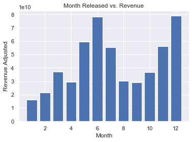

```python
#lets vesualize it to see it clearly
# Now plot these in a bar chart.
sns.set()
plt.bar([1,2,3,4,5,6,7,8,9,10,11,12], month_rev)
plt.title('Month Released vs. Revenue')
plt.ylabel('Revenue Adjusted')
plt.xlabel('Month');
```

> From Data above it appears June and December have the highest revenue for movie releases.

### Research Question 2 : Is the movie runtime affect the its vote?

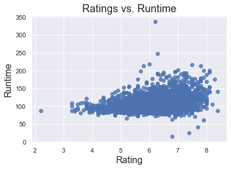

```python
#To get relationship between movie runtime and votes we should visualize this relationship by scatter plot to see it clearly

sns.regplot(x = df['vote_average'], y = df['runtime'], fit_reg = False)
fig_size = plt.rcParams["figure.figsize"]
fig_size[0] = 16
fig_size[1] = 8
plt.rcParams["figure.figsize"] = fig_size
plt.title('Ratings vs. Runtime', fontsize = 18)
plt.xlabel('Rating', fontsize = 16)
plt.ylabel('Runtime', fontsize = 16);
```

> There some outliers i shouldnt consider them in my analysis like movies above 200 min and under 50 min

> Movies with higher time than 100 are likely to have a mid-to-high rating.

```python
#function which will take any column as argument from and keep its track
def calculate_count(column):
    # Convert column to string and seperate it by '|'
    data = df[column].str.cat(sep = '|')

    # Storing the values seperately in a Pandas series
    data = pd.Series(data.split('|'))
    count = data.value_counts(ascending = False)

    return count
```

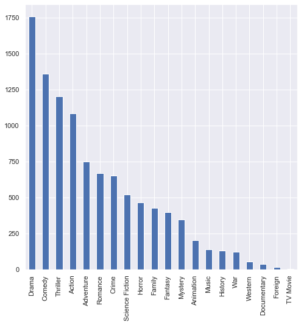

```python
#variable to store the retured value#variabl
count = calculate_count('genres')

count.plot(kind='bar', figsize = (8, 8))
```

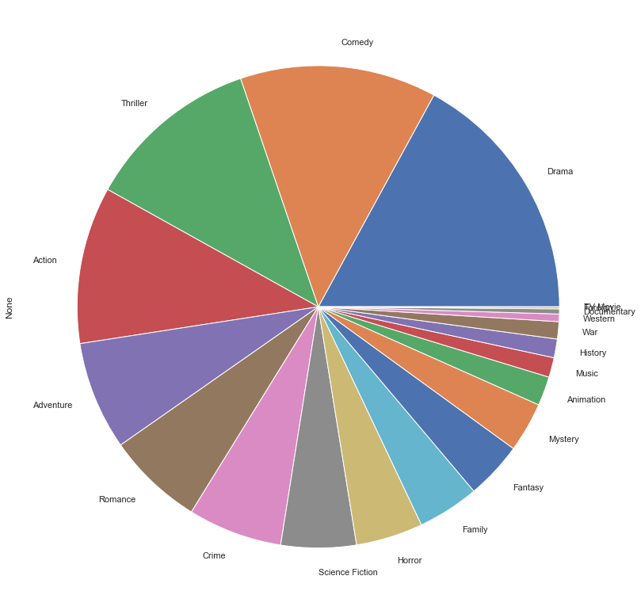

```python
#another visualization
count.plot(kind='pie', figsize = (14, 14))
```

### Research Question 4 :Which variables affect the revenue and popularity of a Movie?

```python
df.corr()
```

|  | id | popularity | budget | revenue | runtime | vote_count | vote_average | release_year | budget_adj | revenue_adj | month |
| --- | --- | --- | --- | --- | --- | --- | --- | --- | --- | --- | --- |
| id | 1.000000 | 0.188878 | -0.027449 | -0.003206 | -0.035688 | 0.111470 | -0.001269 | 0.489926 | -0.124035 | -0.088287 | 0.014805 |
| popularity | 0.188878 | 1.000000 | 0.446987 | 0.615535 | 0.215092 | 0.780096 | 0.317866 | 0.173278 | 0.399356 | 0.546959 | 0.030301 |
| budget | -0.027449 | 0.446987 | 1.000000 | 0.688556 | 0.260977 | 0.556937 | 0.024169 | 0.268040 | 0.958520 | 0.533498 | 0.030141 |
| revenue | -0.003206 | 0.615535 | 0.688556 | 1.000000 | 0.250298 | 0.754567 | 0.227123 | 0.139140 | 0.657567 | 0.900882 | 0.036273 |
| runtime | -0.035688 | 0.215092 | 0.260977 | 0.250298 | 1.000000 | 0.273771 | 0.351712 | -0.112453 | 0.333976 | 0.280505 | 0.172725 |
| vote_count | 0.111470 | 0.780096 | 0.556937 | 0.754567 | 0.273771 | 1.000000 | 0.387210 | 0.207191 | 0.497970 | 0.654688 | 0.012633 |
| vote_average | -0.001269 | 0.317866 | 0.024169 | 0.227123 | 0.351712 | 0.387210 | 1.000000 | -0.134246 | 0.036803 | 0.266844 | 0.124245 |
| release_year | 0.489926 | 0.173278 | 0.268040 | 0.139140 | -0.112453 | 0.207191 | -0.134246 | 1.000000 | 0.075103 | -0.103147 | -0.074866 |
| budget_adj | -0.124035 | 0.399356 | 0.958520 | 0.657567 | 0.333976 | 0.497970 | 0.036803 | 0.075103 | 1.000000 | 0.570451 | 0.057835 |
| revenue_adj | -0.088287 | 0.546959 | 0.533498 | 0.900882 | 0.280505 | 0.654688 | 0.266844 | -0.103147 | 0.570451 | 1.000000 | 0.056241 |
| month | 0.014805 | 0.030301 | 0.030141 | 0.036273 | 0.172725 | 0.012633 | 0.124245 | -0.074866 | 0.057835 | 0.056241 | 1.000000 |

> Regarding to revenue, It has Strong correlation with popularity, budget and vote count and Weak correlation with runtime

#### Lets Visualize few correlations

Strong Correlation between **Revenue** and **Budget**

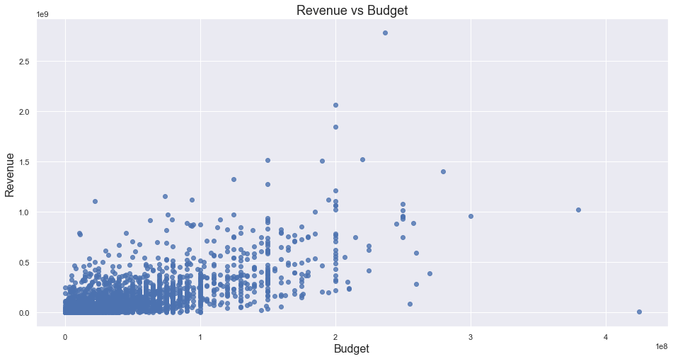

```python
#will use scatter plot to visualize the correlations
sns.regplot(x = df['budget'], y = df['revenue'], fit_reg = False)
fig_size = plt.rcParams["figure.figsize"]
fig_size[0] = 16
fig_size[1] = 8
plt.rcParams["figure.figsize"] = fig_size
plt.title('Revenue vs Budget', fontsize = 18)
plt.xlabel('Budget', fontsize = 16)
plt.ylabel('Revenue', fontsize = 16);
```

Strong Correlation between **Revenue** and **Popularity**

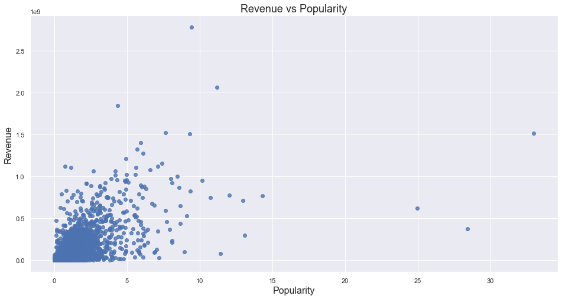

```python
#will use scatter plot to visualize the correlations
sns.regplot(x = df['popularity'], y = df['revenue'], fit_reg = False)
fig_size = plt.rcParams["figure.figsize"]
fig_size[0] = 16
fig_size[1] = 8
plt.rcParams["figure.figsize"] = fig_size
plt.title('Revenue vs Popularity', fontsize = 18)
plt.xlabel('Popularity', fontsize = 16)
plt.ylabel('Revenue', fontsize = 16);
```

Moderate correlation between **Populariy** and **Budget**

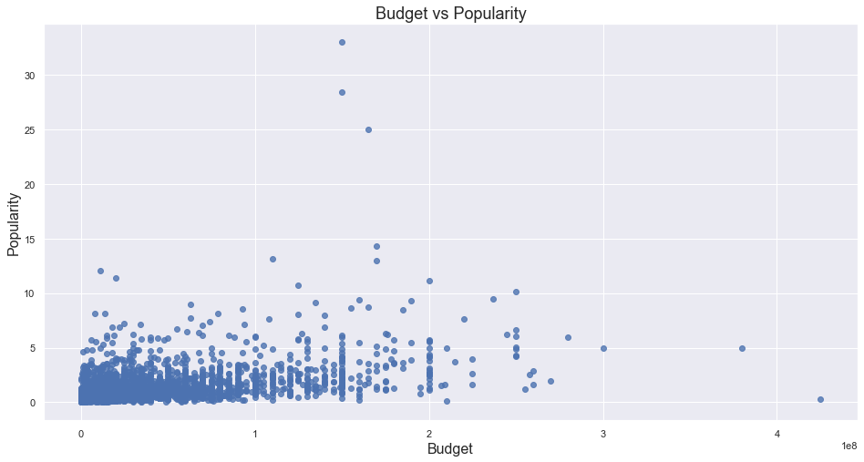

```python
sns.regplot(x = df['budget'], y = df['popularity'], fit_reg = False)
fig_size = plt.rcParams["figure.figsize"]
fig_size[0] = 16
fig_size[1] = 8
plt.rcParams["figure.figsize"] = fig_size
plt.title('Budget vs Popularity', fontsize = 18)
plt.xlabel('Budget', fontsize = 16)
plt.ylabel('Popularity', fontsize = 16);
```

Week Correlation between **Runtime** and **Revenue**

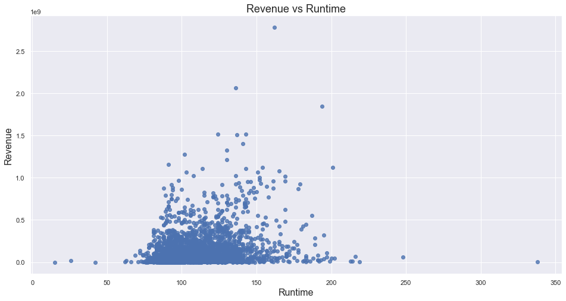

```python
#will use scatter plot to visualize the correlations
sns.regplot(x = df['runtime'], y = df['revenue'], fit_reg = False)
fig_size = plt.rcParams["figure.figsize"]
fig_size[0] = 16
fig_size[1] = 8
plt.rcParams["figure.figsize"] = fig_size
plt.title('Revenue vs Runtime', fontsize = 18)
plt.xlabel('Runtime', fontsize = 16)
plt.ylabel('Revenue', fontsize = 16);
```

### Research Question 5 : What are profit trends from year to year?

```python
# to claculate the profit we must add new column with the profit equation result
#profit equation profit = revenue - budget

df['Profit'] = df['revenue'] - df['budget']

#Ensure that the column
df.head()
```

|  | id | popularity | budget | revenue | original_title | cast | director | keywords | runtime | genres | production_companies | release_date | vote_count | vote_average | release_year | budget_adj | revenue_adj | month | Profit |
| --- | --- | --- | --- | --- | --- | --- | --- | --- | --- | --- | --- | --- | --- | --- | --- | --- | --- | --- | --- |
| 0 | 135397 | 32.985763 | 150000000 | 1513528810 | Jurassic World | Chris Pratt\|Bryce Dallas Howard\|Irrfan Khan\|Vi... | Colin Trevorrow | monster\|dna\|tyrannosaurus rex\|velociraptor\|island | 124 | Action\|Adventure\|Science Fiction\|Thriller | Universal Studios\|Amblin Entertainment\|Legenda... | 2015-06-09 | 5562 | 6.5 | 2015 | 1.379999e+08 | 1.392446e+09 | 6 | 1363528810 |
| 1 | 76341 | 28.419936 | 150000000 | 378436354 | Mad Max: Fury Road | Tom Hardy\|Charlize Theron\|Hugh Keays-Byrne\|Nic... | George Miller | future\|chase\|post-apocalyptic\|dystopia\|australia | 120 | Action\|Adventure\|Science Fiction\|Thriller | Village Roadshow Pictures\|Kennedy Miller Produ... | 2015-05-13 | 6185 | 7.1 | 2015 | 1.379999e+08 | 3.481613e+08 | 5 | 228436354 |
| 2 | 262500 | 13.112507 | 110000000 | 295238201 | Insurgent | Shailene Woodley\|Theo James\|Kate Winslet\|Ansel... | Robert Schwentke | based on novel\|revolution\|dystopia\|sequel\|dyst... | 119 | Adventure\|Science Fiction\|Thriller | Summit Entertainment\|Mandeville Films\|Red Wago... | 2015-03-18 | 2480 | 6.3 | 2015 | 1.012000e+08 | 2.716190e+08 | 3 | 185238201 |
| 3 | 140607 | 11.173104 | 200000000 | 2068178225 | Star Wars: The Force Awakens | Harrison Ford\|Mark Hamill\|Carrie Fisher\|Adam D... | J.J. Abrams | android\|spaceship\|jedi\|space opera\|3d | 136 | Action\|Adventure\|Science Fiction\|Fantasy | Lucasfilm\|Truenorth Productions\|Bad Robot | 2015-12-15 | 5292 | 7.5 | 2015 | 1.839999e+08 | 1.902723e+09 | 12 | 1868178225 |
| 4 | 168259 | 9.335014 | 190000000 | 1506249360 | Furious 7 | Vin Diesel\|Paul Walker\|Jason Statham\|Michelle ... | James Wan | car race\|speed\|revenge\|suspense\|car | 137 | Action\|Crime\|Thriller | Universal Pictures\|Original Film\|Media Rights ... | 2015-04-01 | 2947 | 7.3 | 2015 | 1.747999e+08 | 1.385749e+09 | 4 | 1316249360 |

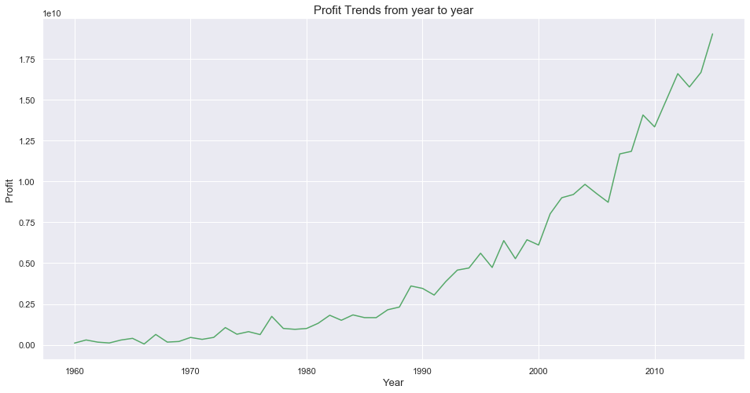

```python
df.groupby('release_year')['Profit'].sum().plot(kind = 'line', figsize = (16, 8), color = 'g')
plt.title('Profit Trends from year to year', fontsize = 15)
plt.xlabel('Year', fontsize = 13)
plt.ylabel('Profit', fontsize = 13);
```

> Profits have increased exponentially over years.

## Conclusions

> The best time to release the moview is June or December.

> Movies with time higher than 100 minutes are likely to have a higher rate.

> Movies that used big budget have highest revenue than others.

> Movies that populare and have more votes have highest revenue than others.

> Movies profits increase exponentially over years.

## Limitations

> The above conclusion is not a 100% accurate, it may has some analysis issue.